# Socio-economic Data Stratification and Comparative Analysis

Alexandre Arcos Pujades

2025-01-29

[figure not shown]

# Introduction

The purpose of this guide is to offer local economic development practitioners a step by step methodology to analyse data of a social and economic nature. It employs a synthetic dataset that mimics a real household survey used in one of the projects implemented by the United Nation’s Human Settlements Programme (UN-Habitat).

The third part of this guide focuses on **stratifying socio-economic data and conducting comparative analysis** to uncover meaningful patterns and disparities within the dataset. Once data has been cleaned and explored, segmenting it into relevant population groups allows for deeper insights into socio-demographic trends, economic inequalities, and policy-relevant findings.

This chapter introduces **stratification techniques**—the process of dividing data into homogeneous subgroups based on key demographic and economic indicators. By applying structured segmentation, we ensure that comparisons are made between groups with similar characteristics, minimizing biases and enhancing analytical rigor.

Effective socio-economic analysis often requires iterative refinement, as data segmentation is shaped by evolving research questions and visualization needs. While not all possible stratifications are relevant for every study, this guide prioritizes those that hold particular value in **sustainable development and international policy contexts**. This structured yet adaptable methodology provides a foundation for practitioners to tailor their analyses to diverse socio-economic and spatial planning challenges.

The comparative analysis builds upon this stratification to examine disparities across population subgroups. It involves:

- **Population segmentation** based on dimensions such as nationality, income level, and marital status.
- **Assessment of vulnerable groups**, including those facing economic hardship and infrastructure deprivation.
- **Income distribution and inequality measures**, including the calculation of Gini coefficients across districts.
- **Educational attainment**, safety perception, and housing affordability, analyzed in relation to socio-economic and demographic characteristics.
- **Work location and commuting patterns**, assessing how employment access varies across different population groups.

By organizing the dataset in this way, we move beyond broad averages and generalizations to pinpoint specific socio-economic disparities. The insights derived from these analyses can inform data-driven decision-making for local economic development, urban planning, and policy interventions.

## Case Description

The fictional country of Lvneel has hired our team to analyse a survey prepared by a local NGO by interviewing a large number of households. The client wants to understand how socio-demographic variables (age, sex, marital status, ethnic group, district…) impact different quality of life indicators.

A summary of the data contained in each variable of the dataset can be found in the [Data Dictionary](https://docs.google.com/spreadsheets/d/1BGSSNHbM8WzLIjpf4B2ypOuXvmSyZsJC/edit?usp=sharing&ouid=105664068897260112805&rtpof=true&sd=true).

# Getting to Know our Data

## Loading Necessary Libraries and Dataset

This step involves loading the dataset we’ll be working with and the libraries that will allow us to manipulate and visualize the data. `tidyverse` includes several packages like `ggplot2` for plotting, and `dplyr` for data manipulation.

```r
# We load necessary libraries for data manipulation and visualization
library(tidyverse)
library(readxl)
library(knitr)
library(forcats)
library(patchwork)

# We load our dataset
hh_survey<-read_xlsx("complete_survey.xlsx")
```

## Population Segmentation by Nationality, Income, and Marital Status

To better understand the composition of our sample, we segmented the population into 36 unique groups, combining three key demographic and socio-economic dimensions:

- **Nationality Group:** Differentiating between land dwellers, sea dwellers, and sky dwellers.
- **Income Group:** Categorizing individuals as low-, medium-, or high-income earners.
- **Marital Status:** Identifying whether respondents are single, married with family in-household, married with family abroad, or prefer not to answer. This classification provides a structured approach to analyzing socio-economic disparities, ensuring that comparisons are made between groups with similar socio-demographic backgrounds.

In the table below, we present:

- The **absolute number of observations** in each category.
- The **in-group percentage**, showing how each marital-income-nationality category is distributed within its respective nationality group.
- The **overall percentage**, reflecting the share of each group relative to the entire dataset.

By structuring the dataset in this way, we can identify key patterns, compare socio-economic characteristics across different communities, and ensure our subsequent analyses are context-aware and representative of the population.

```r
# Compute the total sample size
total_counts <- nrow(hh_survey)

# Compute the count, in-group percentage (within nationality), and overall percentage
summary_table <- hh_survey %>%
  group_by(nationality_group, income_group, marital_status_group) %>%
  summarise(Count = n(), .groups = "drop") %>%
  group_by(nationality_group) %>%  # Group by nationality for correct in-group percentage
  mutate(In_Group_Percentage = (Count / sum(Count)) * 100) %>%
  ungroup() %>%
  mutate(Overall_Percentage = (Count / total_counts) * 100)

# Display the table in a structured format
kable(summary_table, caption = "Population Segmentation by Nationality, Income, and Marital Status")
```

Population Segmentation by Nationality, Income, and Marital Status

| nationality_group | income_group | marital_status_group | Count | In_Group_Percentage | Overall_Percentage |
| --- | --- | --- | --- | --- | --- |
| land_dweller | high_income | Prefer not to answer | 188 | 2.781477 | 1.0162162 |
| land_dweller | high_income | married_family_in | 861 | 12.738571 | 4.6540541 |
| land_dweller | high_income | married_family_out | 403 | 5.962421 | 2.1783784 |
| land_dweller | high_income | single | 532 | 7.870987 | 2.8756757 |
| land_dweller | low_income | Prefer not to answer | 215 | 3.180944 | 1.1621622 |
| land_dweller | low_income | married_family_in | 943 | 13.951768 | 5.0972973 |
| land_dweller | low_income | married_family_out | 524 | 7.752626 | 2.8324324 |
| land_dweller | low_income | single | 748 | 11.066726 | 4.0432432 |
| land_dweller | medium_income | Prefer not to answer | 256 | 3.787542 | 1.3837838 |
| land_dweller | medium_income | married_family_in | 913 | 13.507915 | 4.9351351 |
| land_dweller | medium_income | married_family_out | 479 | 7.086847 | 2.5891892 |
| land_dweller | medium_income | single | 697 | 10.312176 | 3.7675676 |
| sea_dweller | high_income | Prefer not to answer | 138 | 3.097643 | 0.7459459 |
| sea_dweller | high_income | married_family_in | 648 | 14.545454 | 3.5027027 |
| sea_dweller | high_income | married_family_out | 288 | 6.464646 | 1.5567568 |
| sea_dweller | high_income | single | 386 | 8.664422 | 2.0864865 |
| sea_dweller | low_income | Prefer not to answer | 168 | 3.771044 | 0.9081081 |
| sea_dweller | low_income | married_family_in | 690 | 15.488216 | 3.7297297 |
| sea_dweller | low_income | married_family_out | 352 | 7.901235 | 1.9027027 |
| sea_dweller | low_income | single | 559 | 12.547699 | 3.0216216 |
| sea_dweller | medium_income | Prefer not to answer | 115 | 2.581369 | 0.6216216 |
| sea_dweller | medium_income | married_family_in | 526 | 11.806959 | 2.8432432 |
| sea_dweller | medium_income | married_family_out | 245 | 5.499439 | 1.3243243 |
| sea_dweller | medium_income | single | 340 | 7.631874 | 1.8378378 |
| sky_dweller | high_income | Prefer not to answer | 237 | 3.252814 | 1.2810811 |
| sky_dweller | high_income | married_family_in | 1089 | 14.946473 | 5.8864865 |
| sky_dweller | high_income | married_family_out | 493 | 6.766401 | 2.6648649 |
| sky_dweller | high_income | single | 735 | 10.087840 | 3.9729730 |
| sky_dweller | low_income | Prefer not to answer | 247 | 3.390063 | 1.3351351 |
| sky_dweller | low_income | married_family_in | 1059 | 14.534724 | 5.7243243 |
| sky_dweller | low_income | married_family_out | 508 | 6.972276 | 2.7459459 |
| sky_dweller | low_income | single | 805 | 11.048586 | 4.3513514 |
| sky_dweller | medium_income | Prefer not to answer | 185 | 2.539116 | 1.0000000 |
| sky_dweller | medium_income | married_family_in | 875 | 12.009333 | 4.7297297 |
| sky_dweller | medium_income | married_family_out | 416 | 5.709580 | 2.2486486 |
| sky_dweller | medium_income | single | 637 | 8.742794 | 3.4432432 |

# Vulnerable Groups

Understanding vulnerable populations is essential for identifying socio-economic disparities and informing policies aimed at improving living conditions, economic stability, and access to basic services. In this section, we segment the population based on economic and infrastructural vulnerability to gain a deeper understanding of those at risk of social exclusion.

We use two key indicators to assess vulnerability:

- **Economic vulnerability**, measured by the percentage of the population living under the poverty line.
- **Infrastructure deprivation**, analyzed through access to basic services such as electricity, water, sanitation, and internet.

By examining these indicators, we can uncover regional disparities, patterns of exclusion, and areas requiring urgent intervention.

## Percentage of the Population Living Under the Poverty Line by District

A common way to measure economic vulnerability is by identifying those living below the **poverty line**. Here, we define the threshold as **60% of the median income**, a widely used measure for assessing relative poverty. This allows us to compare income distribution across different districts and pinpoint areas where financial hardship is most widespread. By doing this, we gain a clearer understanding of regional economic disparities and where interventions may be most needed.

```r
# Define the poverty threshold as 60% of the median income
poverty_threshold <- 0.6 * median(hh_survey$Informant_income, na.rm = TRUE)

# Compute percentage of population below the poverty line by district
poverty_by_district <- hh_survey %>%
  group_by(District) %>%
  summarise(Percentage_Below_Poverty = mean(Informant_income < poverty_threshold, na.rm = TRUE) * 100) %>%
  arrange(desc(Percentage_Below_Poverty))

# Display results in a table
kable(poverty_by_district, caption = "Percentage of Population Below the Poverty Line by District")
```

Percentage of Population Below the Poverty Line by District

| District | Percentage_Below_Poverty |
| --- | --- |
| Hakumai | 49.005425 |
| Ringo | 24.377510 |
| Kuri | 13.498623 |
| Udon | 6.416223 |
| Kibi | 4.963899 |
| Flower Capital | 2.907296 |

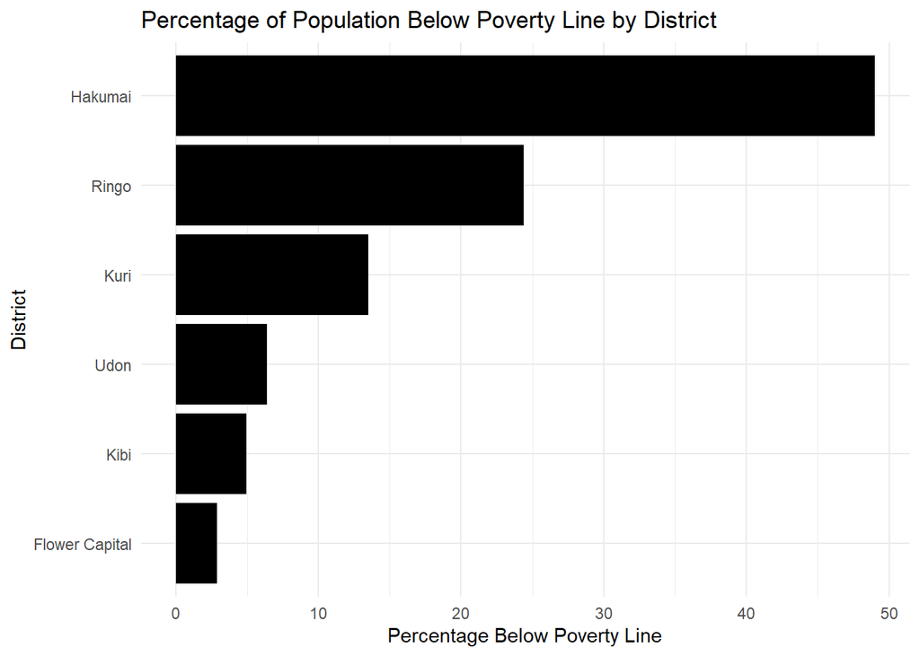

```r
# Plot the results
ggplot(poverty_by_district, aes(x = reorder(District, Percentage_Below_Poverty), y = Percentage_Below_Poverty)) +
  geom_bar(stat = "identity", fill = "black") +
  coord_flip() +  # Horizontal bars for better readability
  labs(title = "Percentage of Population Below Poverty Line by District",
       x = "District",
       y = "Percentage Below Poverty Line") +
  theme_minimal()
```

## Percentage of the Population Without Access to Basic Services by District

Income alone does not capture the full picture of vulnerability—many households, regardless of earnings, face difficulties if they lack essential services. In this section, we analyze the percentage of people without **access to electricity, clean water, sanitation, and internet**. Comparing these figures across districts helps identify areas where infrastructure gaps are most severe and whether they align with patterns of poverty.

By looking at both economic and infrastructural challenges, we gain a more complete understanding of the population’s living conditions and where targeted action can make the biggest difference.

```r
# Compute the percentage of population lacking each service by district
services_access <- hh_survey %>%
  group_by(District) %>%
  summarise(
    No_Electricity = mean(is.na(Utility_electricity_available) | Utility_electricity_available == "", na.rm = TRUE) * 100,
    No_Water = mean(is.na(Utility_water_available) | Utility_water_available == "", na.rm = TRUE) * 100,
    No_Sanitation = mean(is.na(Utility_sanitation_available) | Utility_sanitation_available == "", na.rm = TRUE) * 100,
    No_Internet = mean(is.na(Internet_hotspot) & is.na(Internet_WiFi), na.rm = TRUE) * 100  # Lacking both internet options
  ) %>%
  arrange(desc(No_Electricity))  # Sort by most deprived in electricity access

# Display results in a table
kable(services_access, caption = "Percentage of Population Without Access to Basic Services by District")
```

Percentage of Population Without Access to Basic Services by District

| District | No_Electricity | No_Water | No_Sanitation | No_Internet |
| --- | --- | --- | --- | --- |
| Hakumai | 15.117541 | 21.591320 | 13.960217 | 5.533454 |
| Ringo | 13.172691 | 14.859438 | 10.321285 | 5.943775 |
| Kibi | 11.371841 | 2.045728 | 5.385078 | 4.963899 |
| Kuri | 6.366697 | 7.009489 | 4.775023 | 2.754821 |
| Udon | 5.219415 | 7.180851 | 4.820479 | 2.726064 |
| Flower Capital | 4.827208 | 0.000000 | 4.717499 | 2.386177 |

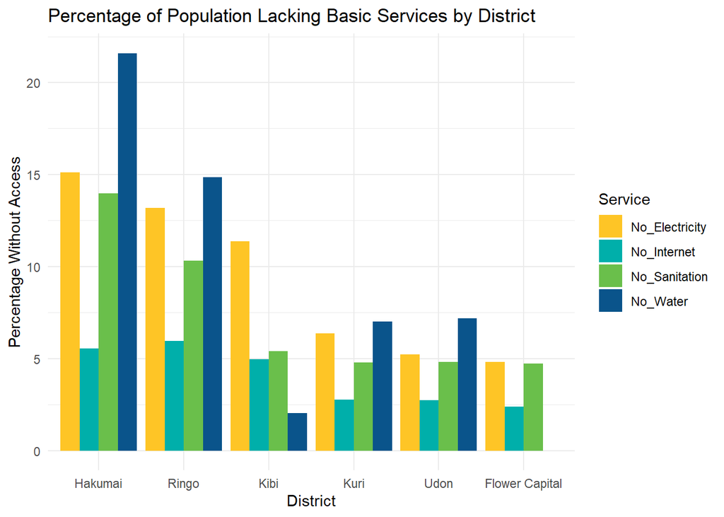

```r
# Convert data to long format for visualization
services_access_long <- services_access %>%
  pivot_longer(cols = c(No_Electricity, No_Water, No_Sanitation, No_Internet), names_to = "Service", values_to = "Percentage_Lacking")

# Define custom colors
colors <- c("No_Electricity" = "#FEC526", "No_Water" = "#0A548B", "No_Sanitation" = "#6ABF4B", "No_Internet" = "#00AFAA")

# Plot the percentage of people lacking basic services by district
ggplot(services_access_long, aes(x = reorder(District, -Percentage_Lacking), y = Percentage_Lacking, fill = Service)) +
  geom_bar(stat = "identity", position = "dodge") +
  labs(title = "Percentage of Population Lacking Basic Services by District",
       x = "District",
       y = "Percentage Without Access") +
  theme_minimal() +
  scale_fill_manual(values = colors)
```

# Housing Affordability and Rent Burden

Housing affordability is a critical factor in assessing economic well-being, particularly for vulnerable populations. A common measure of housing stress is **rent burden**, which occurs when a **household spends more than 30% of its income on rent**. Excessive rent costs can lead to financial instability, limiting access to other essential needs such as healthcare, education, and savings.

This section analyzes rent burden across districts, first by looking at the overall population, and then focusing specifically on low-income households. By comparing these groups, we can identify where rent burden is most severe and whether it disproportionately affects economically disadvantaged residents. This insight is essential for urban planners and policymakers seeking to implement housing affordability policies.

```r
# Define rent burden threshold (keeping only >30% since >50% has no values)
rent_burden_threshold <- 0.3  # Households spending more than 30% of income on rent

# Adjust for income-rent time scale (since rent is annual, divide by 12)
hh_survey <- hh_survey %>%
    mutate(Monthly_Rent = AnnualRent / 12)

### ✅ 1. Rent Burden for All Households by District ###
rent_burden_by_district <- hh_survey %>%
    filter(!is.na(Monthly_Rent) & !is.na(hh_income) & hh_income > 0) %>%
    group_by(District) %>%
    summarise(Rent_Burdened = mean((Monthly_Rent / hh_income) > rent_burden_threshold, na.rm = TRUE) * 100) %>%
    arrange(desc(Rent_Burdened))

# Display table
kable(rent_burden_by_district, caption = "Percentage of Rent-Burdened Households by District (All Households)")
```

Percentage of Rent-Burdened Households by District (All Households)

| District | Rent_Burdened |
| --- | --- |
| Hakumai | 72.51356 |
| Ringo | 71.08434 |
| Kibi | 70.87846 |
| Kuri | 54.11693 |
| Udon | 44.48138 |
| Flower Capital | 43.30773 |

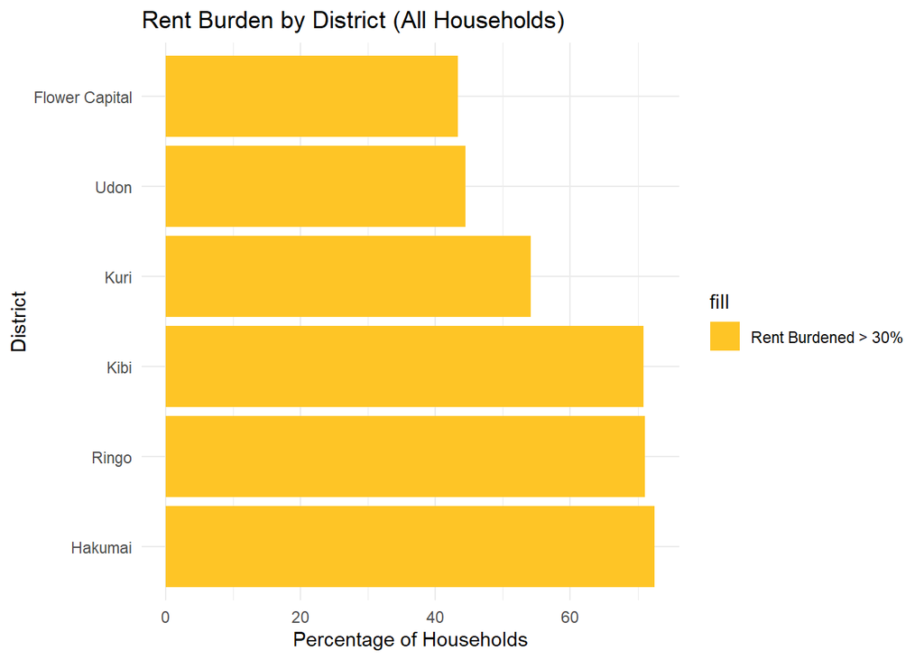

```r
# Plot rent burden for all households
ggplot(rent_burden_by_district, aes(x = reorder(District, -Rent_Burdened), y = Rent_Burdened, fill = "Rent Burdened > 30%")) +
    geom_bar(stat = "identity") +
    scale_fill_manual(values = c("Rent Burdened > 30%" = "#FEC526")) +
    coord_flip() +
    labs(title = "Rent Burden by District (All Households)", x = "District", y = "Percentage of Households") +
    theme_minimal()
```

```r
### ✅ 2. Rent Burden for Low-Income Households by District ###
low_income_rent_burden <- hh_survey %>%
    filter(!is.na(Monthly_Rent) & !is.na(hh_income) & hh_income > 0 & income_group == "low_income") %>%  # Fixed filter
    group_by(District) %>%
    summarise(Low_Income_Rent_Burdened = mean((Monthly_Rent / hh_income) > rent_burden_threshold, na.rm = TRUE) * 100) %>%
    arrange(desc(Low_Income_Rent_Burdened))

# Display table
kable(low_income_rent_burden, caption = "Percentage of Rent-Burdened Households by District (Low-Income Only)")
```

Percentage of Rent-Burdened Households by District (Low-Income Only)

| District | Low_Income_Rent_Burdened |
| --- | --- |
| Udon | 74.83617 |
| Hakumai | 74.17187 |
| Ringo | 74.03983 |
| Kibi | 73.13770 |
| Kuri | 72.88344 |
| Flower Capital | 72.36994 |

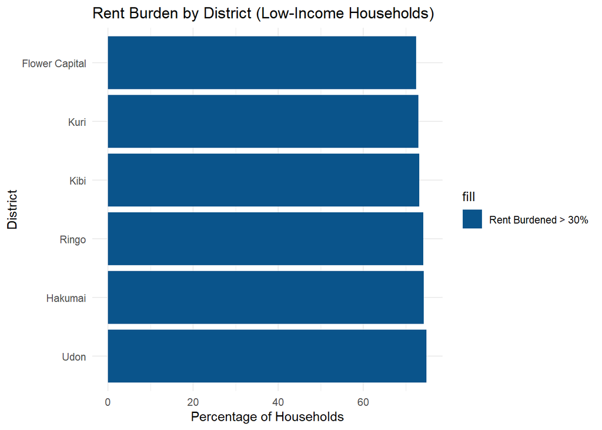

```r
# If no data is found, print a message
if (nrow(low_income_rent_burden) == 0) {
    print("No low-income households found meeting the rent burden criteria.")
} else {
    # Plot rent burden for low-income households
    ggplot(low_income_rent_burden, aes(x = reorder(District, -Low_Income_Rent_Burdened), y = Low_Income_Rent_Burdened, fill = "Rent Burdened > 30%")) +
        geom_bar(stat = "identity") +
        scale_fill_manual(values = c("Rent Burdened > 30%" = "#0A548B")) +
        coord_flip() +
        labs(title = "Rent Burden by District (Low-Income Households)", x = "District", y = "Percentage of Households") +
        theme_minimal()
}
```

# Income Distribution

Understanding the distribution of income levels across different segments of the population is crucial for identifying economic disparities and designing inclusive policies. Income inequality can shape access to housing, education, and public services, influencing overall social and economic stability.

In this section, we examine how income levels are distributed within two key dimensions:

- **By Nationality** – to see if certain ethnic groups are disproportionately represented in lower or higher income brackets.
- **By District** – to analyze whether specific regions exhibit higher economic inequality than others.

Using **stacked bar charts**, we visualize the proportion of low-income, medium-income, and high-income individuals within each group. This helps us pinpoint areas of concentrated wealth and economic disadvantage, offering insights for targeted policy interventions.

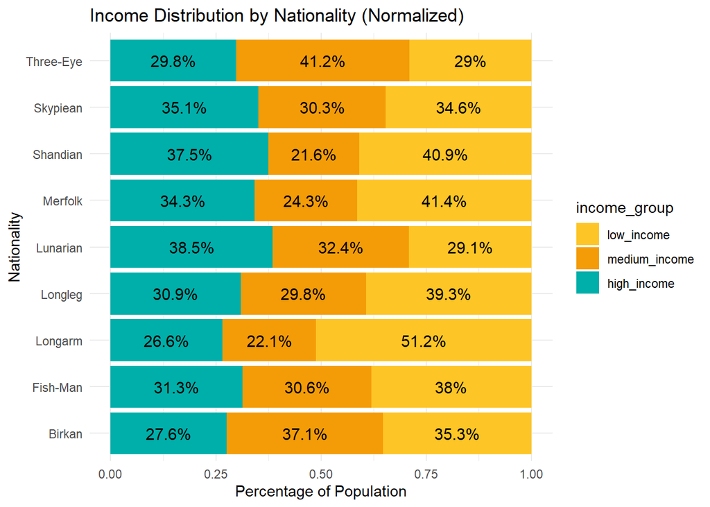

```r
# Compute the total population within each nationality & district
total_by_nationality <- hh_survey %>%
  group_by(Informant_nationality) %>%
  summarise(Total_Population = n(), .groups = "drop")

total_by_district <- hh_survey %>%
  group_by(District) %>%
  summarise(Total_Population = n(), .groups = "drop")

# Compute the percentage of each income group **within each nationality**
income_by_nationality <- hh_survey %>%
  group_by(Informant_nationality, income_group) %>%
  summarise(Count = n(), .groups = "drop") %>%
  left_join(total_by_nationality, by = "Informant_nationality") %>%
  mutate(Percentage = (Count / Total_Population) * 100,
         Label = paste0(round(Percentage, 1), "%"))  # Create labels with 1 decimal point

# Compute the percentage of each income group **within each district**
income_by_district <- hh_survey %>%
  group_by(District, income_group) %>%
  summarise(Count = n(), .groups = "drop") %>%
  left_join(total_by_district, by = "District") %>%
  mutate(Percentage = (Count / Total_Population) * 100,
         Label = paste0(round(Percentage, 1), "%"))  # Create labels with 1 decimal point

# Define custom colors for income levels
income_colors <- c("low_income" = "#FEC526",    # Yellow (Top)
                   "medium_income" = "#F49C08", # Orange (Middle)
                   "high_income" = "#00AFAA")   # Teal (Bottom)

# Reorder income levels so "low_income" is at the bottom, "high_income" at the top
income_by_nationality$income_group <- factor(income_by_nationality$income_group,
                                             levels = c("low_income", "medium_income", "high_income"))
income_by_district$income_group <- factor(income_by_district$income_group,
                                          levels = c("low_income", "medium_income", "high_income"))

### Stacked Bar Chart: Income Distribution by Nationality (100% Scale + Labels)
ggplot(income_by_nationality, aes(x = Informant_nationality, y = Percentage, fill = income_group)) +
  geom_bar(stat = "identity", position = "fill") +  # "fill" ensures all bars are 100% in length
  geom_text(aes(label = Label), position = position_fill(vjust = 0.5), size = 4, color = "black") +  # Add labels inside bars
  scale_fill_manual(values = income_colors) +
  coord_flip() +
  labs(title = "Income Distribution by Nationality (Normalized)", x = "Nationality", y = "Percentage of Population") +
  theme_minimal()
```

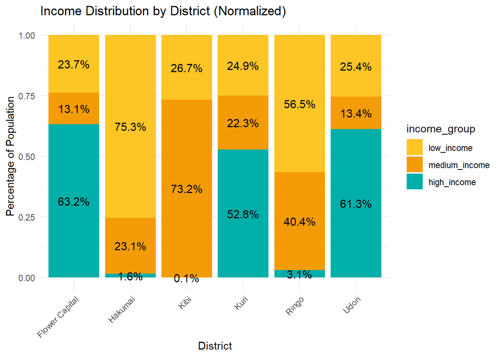

```r
### Stacked Bar Chart: Income Distribution by District (100% Scale + Labels)
ggplot(income_by_district, aes(x = District, y = Percentage, fill = income_group)) +
  geom_bar(stat = "identity", position = "fill") +  # "fill" ensures all bars are 100% in length
  geom_text(aes(label = Label), position = position_fill(vjust = 0.5), size = 4, color = "black") +  # Add labels inside bars
  scale_fill_manual(values = income_colors) +
  labs(title = "Income Distribution by District (Normalized)", x = "District", y = "Percentage of Population") +
  theme_minimal() +
  theme(axis.text.x = element_text(angle = 45, hjust = 1))  # Rotate x-axis labels for readability
```

# Income Inequality: Gini Coefficients by District

Income inequality is a key indicator of economic disparity within a population. While measures like poverty rates help identify those struggling the most, they do not capture the distribution of income across the entire society. The **Gini coefficient** provides a way to quantify inequality by measuring how unevenly income is distributed, with values ranging from 0 (perfect equality) to 1 (maximum inequality, where one person holds all the income).

In this section, we calculate the overall Gini coefficient for the entire dataset and break it down by district to examine how inequality varies across different geographic areas. This allows us to see which districts have the largest income disparities and how inequality patterns align with other socio-economic factors such as poverty and access to services. While a higher Gini coefficient indicates greater disparity, it does not necessarily imply higher poverty—some districts may have high inequality due to a mix of very wealthy and middle-income residents, while others may have low inequality because most residents earn similar, but very low, wages.

By analyzing income inequality at multiple levels, we can gain a deeper understanding of how economic resources are distributed and which areas might require targeted policy interventions to promote more inclusive growth.

```r
# Load necessary library
library(ineq)


# Compute the overall Gini coefficient for the entire dataset
gini_overall <- ineq(hh_survey$Informant_income, type = "Gini", na.rm = TRUE)

# Compute Gini coefficient for each district
gini_by_district <- hh_survey %>%
  group_by(District) %>%
  summarise(Gini_Coefficient = ineq(Informant_income, type = "Gini", na.rm = TRUE)) %>%
  arrange(desc(Gini_Coefficient))  # Sort from highest inequality to lowest

# Display results in a table
kable(gini_by_district, caption = "Gini Coefficient by District")
```

Gini Coefficient by District

| District | Gini_Coefficient |
| --- | --- |
| Udon | 0.3495712 |
| Flower Capital | 0.3432492 |
| Kuri | 0.3254657 |
| Hakumai | 0.2804156 |
| Ringo | 0.2415053 |
| Kibi | 0.1482799 |

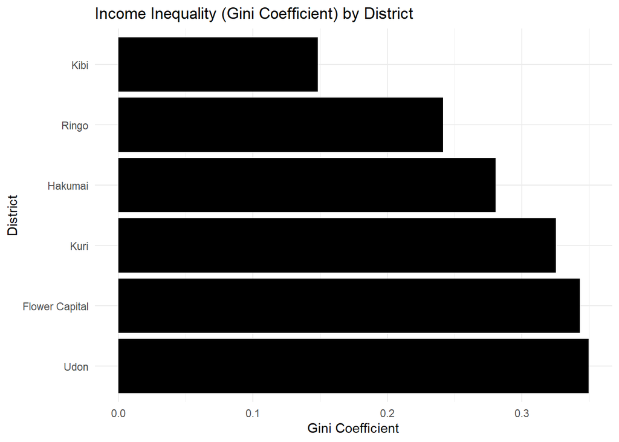

```r
# Plot Gini coefficients by district
ggplot(gini_by_district, aes(x = reorder(District, -Gini_Coefficient), y = Gini_Coefficient)) +
  geom_bar(stat = "identity", fill = "black") +
  coord_flip() +  # Horizontal bars for readability
  labs(title = "Income Inequality (Gini Coefficient) by District",
       x = "District",
       y = "Gini Coefficient") +
  theme_minimal()
```

```r
# Print overall Gini coefficient
print(paste("Overall Gini Coefficient:", round(gini_overall, 3)))
```

```
## [1] "Overall Gini Coefficient: 0.387"
```

# Educational Attainment

Education plays a crucial role in shaping economic opportunities, career trajectories, and overall social mobility. Analyzing the distribution of educational attainment across different income groups and genders helps us understand whether disparities exist in access to education and how they translate into economic outcomes.

This section explores:

- **How education levels vary by income group** – Do higher-income individuals have significantly greater access to higher education?
- **How education levels differ by gender** – Are there notable differences in educational attainment between men and women?
- **How education levels differ by nationality group** – Are there notable differences in educational attainment among broad ethnic groups?

Using **100% stacked bar charts**, we visualize the proportion of individuals in each education category across income levels and gender, helping us identify patterns of educational inequality.

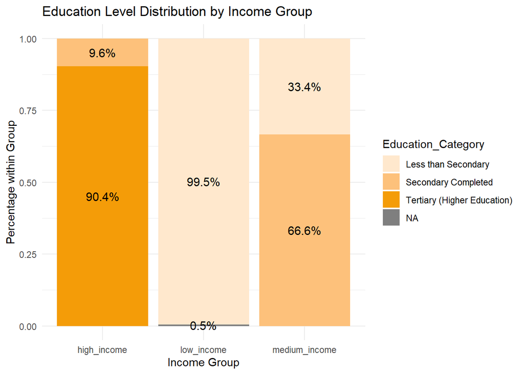

```r
# Reclassify education levels into three broader categories
hh_survey <- hh_survey %>%
  mutate(Education_Category = case_when(
    Informant_edulevel %in% c("Less than primary school", "No formal schooling (can read and write)",
                              "No formal schooling (cannot read and write)",
                              "Primary school completed (first to 6th grade)",
                              "Intermediate school completed (7th to 9th grade)") ~ "Less than Secondary",
    Informant_edulevel == "Secondary school completed (10th to 12th grade)" ~ "Secondary Completed",
    Informant_edulevel %in% c("Diploma (technical/vocational training)",
                              "College/University completed",
                              "Masters/high diploma completed",
                              "Doctorate completed") ~ "Tertiary (Higher Education)"
  ))

# Compute total counts within each income group & gender for correct normalization
total_by_income <- hh_survey %>%
  group_by(income_group) %>%
  summarise(Total = n(), .groups = "drop")

total_by_gender <- hh_survey %>%
  group_by(InformantGender) %>%
  summarise(Total = n(), .groups = "drop")

# Compute total counts within each nationality group for correct normalization
total_by_nationality <- hh_survey %>%
  group_by(nationality_group) %>%
  summarise(Total = n(), .groups = "drop")

# Compute the percentage of each education category **within each income group**
edu_by_income <- hh_survey %>%
  group_by(income_group, Education_Category) %>%
  summarise(Count = n(), .groups = "drop") %>%
  left_join(total_by_income, by = "income_group") %>%
  mutate(Percentage = (Count / Total) * 100,
         Label = paste0(round(Percentage, 1), "%"))  # Create percentage labels

# Compute the percentage of each education category **within each gender**
edu_by_gender <- hh_survey %>%
  group_by(InformantGender, Education_Category) %>%
  summarise(Count = n(), .groups = "drop") %>%
  left_join(total_by_gender, by = "InformantGender") %>%
  mutate(Percentage = (Count / Total) * 100,
         Label = paste0(round(Percentage, 1), "%"))  # Create percentage labels

# Compute the percentage of each education category within each nationality group
edu_by_nationality <- hh_survey %>%
  group_by(nationality_group, Education_Category) %>%
  summarise(Count = n(), .groups = "drop") %>%
  left_join(total_by_nationality, by = "nationality_group") %>%
  mutate(Percentage = (Count / Total) * 100,
         Label = paste0(round(Percentage, 1), "%"))  # Create percentage labels

# Define custom colors for education levels
edu_colors <- c("Less than Secondary" = "#FFE8CD",
                "Secondary Completed" = "#FDC17B",
                "Tertiary (Higher Education)" = "#F49C08")

### 100% Stacked Bar Chart: Education Level by Income Group (Corrected Percentages)
ggplot(edu_by_income, aes(x = income_group, y = Percentage, fill = Education_Category)) +
  geom_bar(stat = "identity", position = "fill") +  # 100% stacked bars
  geom_text(aes(label = Label), position = position_fill(vjust = 0.5), size = 4, color = "black") +  # Add percentage labels
  scale_fill_manual(values = edu_colors) +
  labs(title = "Education Level Distribution by Income Group", x = "Income Group", y = "Percentage within Group") +
  theme_minimal()
```

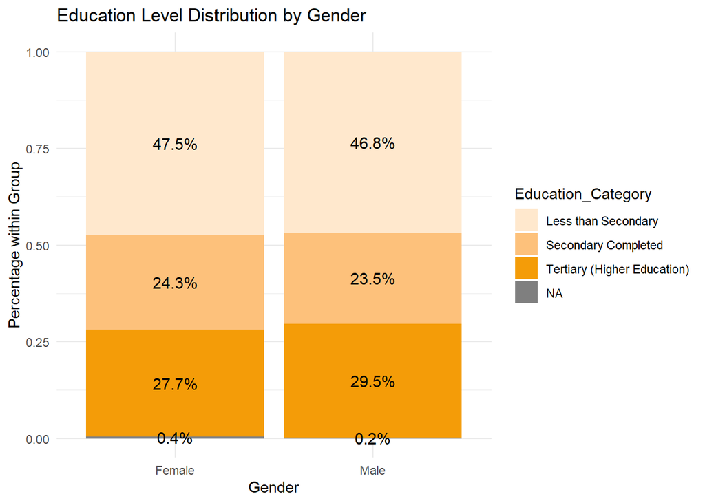

```r
### 100% Stacked Bar Chart: Education Level by Gender (Corrected Percentages)
ggplot(edu_by_gender, aes(x = InformantGender, y = Percentage, fill = Education_Category)) +
  geom_bar(stat = "identity", position = "fill") +  # 100% stacked bars
  geom_text(aes(label = Label), position = position_fill(vjust = 0.5), size = 4, color = "black") +  # Add percentage labels
  scale_fill_manual(values = edu_colors) +
  labs(title = "Education Level Distribution by Gender", x = "Gender", y = "Percentage within Group") +
  theme_minimal()
```

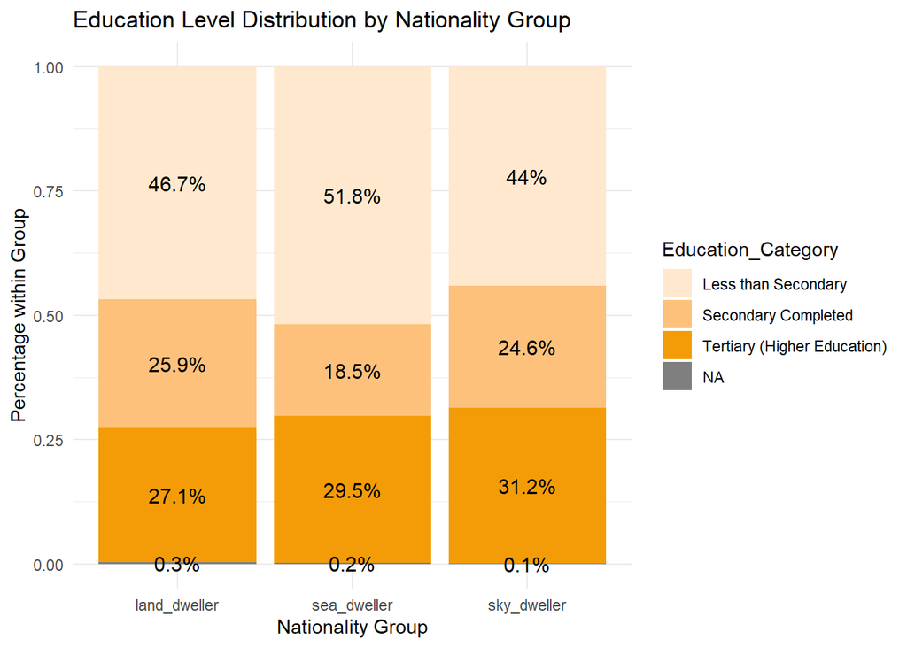

```r
### 100% Stacked Bar Chart: Education Level by Nationality Group
ggplot(edu_by_nationality, aes(x = nationality_group, y = Percentage, fill = Education_Category)) +
    geom_bar(stat = "identity", position = "fill") +  # 100% stacked bars
    geom_text(aes(label = Label), position = position_fill(vjust = 0.5), size = 4, color = "black") +  # Add percentage labels
    scale_fill_manual(values = edu_colors) +
    labs(title = "Education Level Distribution by Nationality Group", x = "Nationality Group", y = "Percentage within Group") +
    theme_minimal()
```

# Age Distribution Across Key Demographic and Socioeconomic Groups

Age plays a crucial role in shaping social and economic behaviors, influencing factors such as employment opportunities, household composition, and financial stability. Understanding the average age distribution across different population segments provides insight into demographic trends, economic maturity, and potential generational disparities.

In this section, we analyze the average age across three key dimensions:

- **Marital Status Group:** Exploring how age varies between single, married, and other household compositions.
- **Nationality Group:** Identifying age differences across different ethnic or national communities.
- **Income Group:** Examining whether higher income groups tend to be older, reflecting career progression and experience.

As we were expecting, high-income individuals are, on average, older than low- and medium-income ones. There are noticeable differences between nationality groups, and when it comes to marital status, those married with their families inside the country are 2.5 years older on average than those married, but with their families outside.

```r
# Compute average age by marital status group
avg_age_by_marital <- hh_survey %>%
  group_by(marital_status_group) %>%
  summarise(Average_Age = mean(InformantAge, na.rm = TRUE), .groups = "drop") %>%
  arrange(desc(Average_Age))

# Compute average age by nationality group
avg_age_by_nationality <- hh_survey %>%
  group_by(nationality_group) %>%
  summarise(Average_Age = mean(InformantAge, na.rm = TRUE), .groups = "drop") %>%
  arrange(desc(Average_Age))

# Compute average age by income group
avg_age_by_income <- hh_survey %>%
  group_by(income_group) %>%
  summarise(Average_Age = mean(InformantAge, na.rm = TRUE), .groups = "drop") %>%
  arrange(desc(Average_Age))

# Display the results in tables
kable(avg_age_by_marital, caption = "Average Age by Marital Status Group")
```

Average Age by Marital Status Group

| marital_status_group | Average_Age |
| --- | --- |
| married_family_in | 35.65216 |
| Prefer not to answer | 34.30074 |
| single | 34.01581 |
| married_family_out | 33.19498 |

```r
kable(avg_age_by_nationality, caption = "Average Age by Nationality Group")
```

Average Age by Nationality Group

| nationality_group | Average_Age |
| --- | --- |
| sky_dweller | 34.91642 |
| land_dweller | 34.44296 |
| sea_dweller | 34.11650 |

```r
kable(avg_age_by_income, caption = "Average Age by Income Group")
```

Average Age by Income Group

| income_group | Average_Age |
| --- | --- |
| high_income | 38.98583 |
| low_income | 32.43635 |
| medium_income | 32.40711 |

# Marital Status Distribution

Marital status is an important demographic factor that influences household composition, economic stability, and social behavior. Understanding how marital status is distributed within different income and nationality groups provides insights into family structures and potential socio-economic trends.

This section examines:

- **How marital status varies by income level** – Are higher-income groups more likely to be married, or does singlehood dominate across all income categories?
- **How marital status is distributed across nationality groups** – Do different cultural or ethnic backgrounds show distinct marriage patterns?

To visualize these relationships, we use **pie charts** that represent the percentage of each marital status category within income groups (low, medium, high) and nationality groups (land dweller, sea dweller, sky dweller). These charts help illustrate differences in family structures and provide a foundation for further socio-economic analysis.

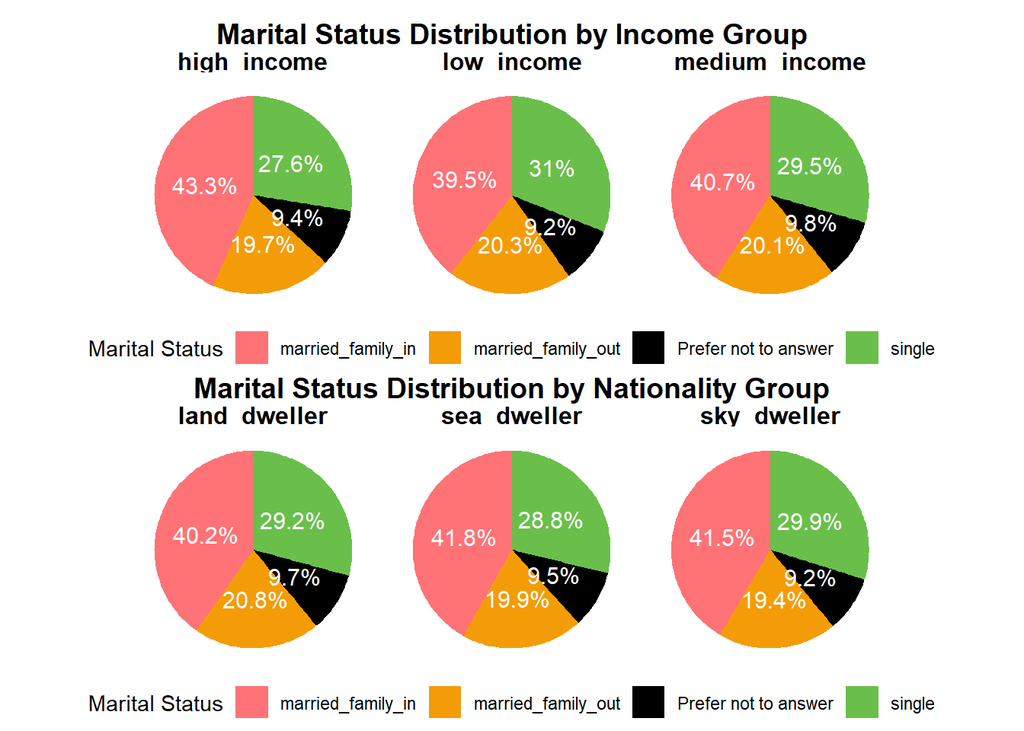

```r
# Load necessary libraries
library(dplyr)
library(ggplot2)
library(patchwork)  # For arranging multiple plots

# Define custom colors for marital status categories
marital_colors <- c("married_family_in" = "#FF7276",
                    "married_family_out" = "#F49C08",
                    "single" = "#6ABF4B",
                    "Prefer not to answer" = "black")

# Compute the percentage of each marital status group within each income group
marital_by_income <- hh_survey %>%
  group_by(income_group, marital_status_group) %>%
  summarise(Count = n(), .groups = "drop") %>%
  group_by(income_group) %>%
  mutate(Percentage = (Count / sum(Count)) * 100,
         Label = paste0(round(Percentage, 1), "%"))

# Compute the percentage of each marital status group within each nationality group
marital_by_nationality <- hh_survey %>%
  group_by(nationality_group, marital_status_group) %>%
  summarise(Count = n(), .groups = "drop") %>%
  group_by(nationality_group) %>%
  mutate(Percentage = (Count / sum(Count)) * 100,
         Label = paste0(round(Percentage, 1), "%"))

# Function to create faceted pie charts
create_pie_faceted <- function(data, group_var, title_prefix) {
  ggplot(data, aes(x = "", y = Percentage, fill = marital_status_group)) +
    geom_bar(stat = "identity", width = 1) +
    coord_polar(theta = "y", start = 0) +
    scale_fill_manual(values = marital_colors) +
    facet_wrap(as.formula(paste("~", group_var)), ncol = 3) +  # Separate facets for each category
    labs(title = title_prefix, fill = "Marital Status") +
    geom_text(aes(label = ifelse(Percentage > 5, Label, "")),
              position = position_stack(vjust = 0.5),
              color = "white", size = 4) +
    theme_void() +
    theme(
      plot.title = element_text(hjust = 0.5, face = "bold", size = 14),
      strip.text = element_text(face = "bold", size = 12),
      legend.position = "bottom"
    )
}

# Generate separate faceted pie charts
pie_income <- create_pie_faceted(marital_by_income, "income_group", "Marital Status Distribution by Income Group")
pie_nationality <- create_pie_faceted(marital_by_nationality, "nationality_group", "Marital Status Distribution by Nationality Group")

# Display both plots one below the other
pie_income / pie_nationality
```

# Safety Perception and Reported Insecurity Issues

## Reported Security Issues by District

Security concerns play a significant role in shaping individuals’ quality of life and mobility choices. By analyzing reports of specific security incidents—such as **home robberies, physical attacks, and harassment**—we can identify which districts experience higher levels of insecurity. The following visualization presents a breakdown of reported security issues across districts, highlighting which types of crimes are most frequently recorded.

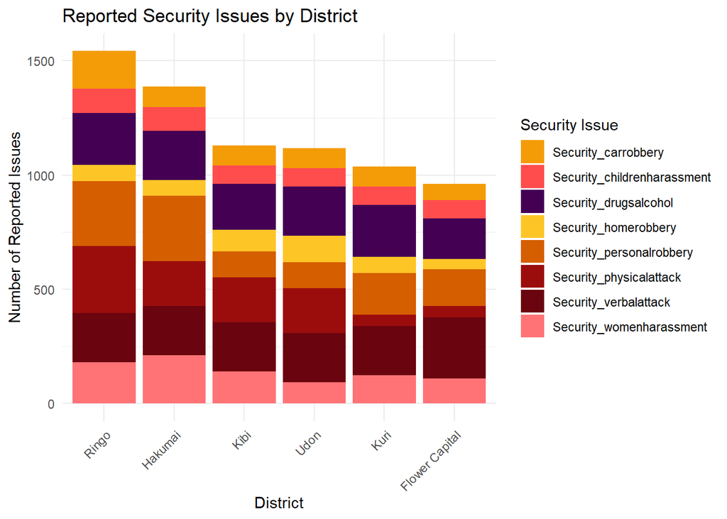

```r
# Select only the security-related columns
security_columns <- c("Security_homerobbery", "Security_carrobbery", "Security_personalrobbery",
                      "Security_womenharassment", "Security_childrenharassment", "Security_physicalattack",
                      "Security_verbalattack", "Security_drugsalcohol")

# Reshape the data to long format for easier visualization
security_long <- hh_survey %>%
    select(District, all_of(security_columns)) %>%
    pivot_longer(cols = all_of(security_columns), names_to = "Security_Issue", values_to = "Selected") %>%
    filter(Selected == "Select") %>%  # Keep only selected cases
    group_by(District, Security_Issue) %>%
    summarise(Count = n(), .groups = "drop")

# Define custom colors for each security issue
security_colors <- c("Security_homerobbery" = "#FEC526",
                     "Security_carrobbery" = "#F49C08",
                     "Security_personalrobbery" = "#D55E00",
                     "Security_womenharassment" = "#FF7276",
                     "Security_childrenharassment" = "#FF4D4D",
                     "Security_physicalattack" = "#9B0D0D",
                     "Security_verbalattack" = "#6A040F",
                     "Security_drugsalcohol" = "#440154")

# Create the stacked bar chart
ggplot(security_long, aes(x = reorder(District, -Count), y = Count, fill = Security_Issue)) +
    geom_bar(stat = "identity", position = "stack") +
    scale_fill_manual(values = security_colors) +
    labs(title = "Reported Security Issues by District",
         x = "District",
         y = "Number of Reported Issues",
         fill = "Security Issue") +
    theme_minimal() +
    theme(axis.text.x = element_text(angle = 45, hjust = 1))
```

## Perceived Safety by District

While crime reports provide an objective measure of security, safety perceptions can vary significantly based on personal experiences and local conditions. The following analysis aggregates survey responses to determine the average safety perception score for each district, giving insight into which areas are considered safe or unsafe by residents.

In our case, we find interesting **contrasts between the insecurity reports and the perceived safety** of the different districts. “Ringo” having the lowest safety perception is consistent with it being the most insecure district according to the security reports. However, in the case of “Hakumai” and “Kibi”, we notice that they are perceived as being the safest districts although the reports seem to contradict that reality.

```r
# Compute the average safety perception for each district
avg_safety_per_district <- hh_survey %>%
    group_by(District) %>%
    summarise(Average_Safety_Score = mean(as.numeric(NeighSafety), na.rm = TRUE), .groups = "drop") %>%
    arrange(Average_Safety_Score)  # Order from least to most safe

# Display results in a table
kable(avg_safety_per_district, caption = "Average Safety Perception by District")
```

Average Safety Perception by District

| District | Average_Safety_Score |
| --- | --- |
| Ringo | 3.071888 |
| Udon | 3.084109 |
| Flower Capital | 3.106966 |
| Kuri | 3.119988 |
| Kibi | 3.136282 |
| Hakumai | 3.154792 |

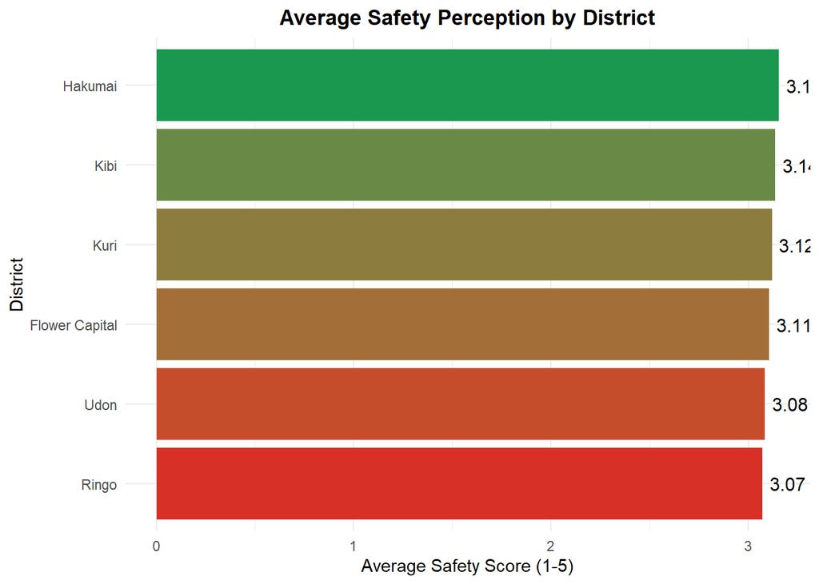

```r
# Create a bar plot of safety perception with labels
ggplot(avg_safety_per_district, aes(x = reorder(District, Average_Safety_Score), y = Average_Safety_Score, fill = Average_Safety_Score)) +
    geom_bar(stat = "identity", show.legend = FALSE) +
    geom_text(aes(label = round(Average_Safety_Score, 2)), hjust = -0.2, size = 4) +  # Add labels next to bars
    scale_fill_gradient(low = "#D73027", high = "#1A9850") +  # Red for low safety, green for high safety
    labs(title = "Average Safety Perception by District", x = "District", y = "Average Safety Score (1-5)") +
    coord_flip() +  # Horizontal bars for better readability
    theme_minimal() +
    theme(plot.title = element_text(hjust = 0.5, face = "bold"))
```

## Safety Perception Across Different Population Groups

Perceptions of safety are not uniform across all demographic groups. Factors such as **gender, income level, age, and marital status can influence how individuals assess their personal security**. The following stacked bar charts illustrate the relative distribution of safety perceptions within different groups, alongside the average safety score for each category.

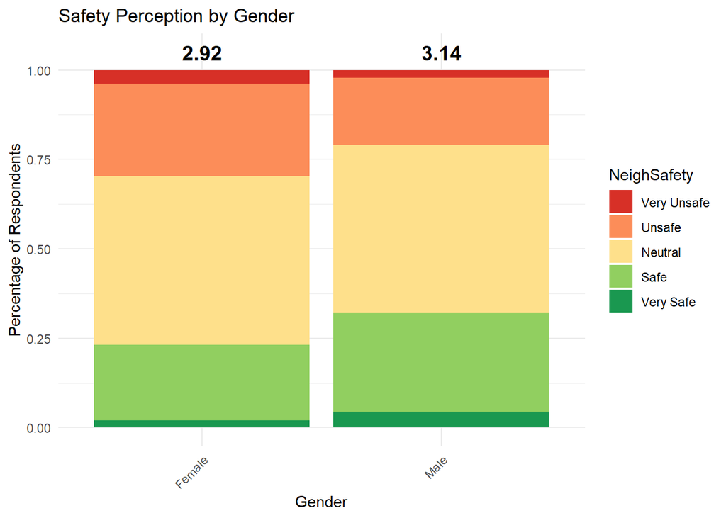

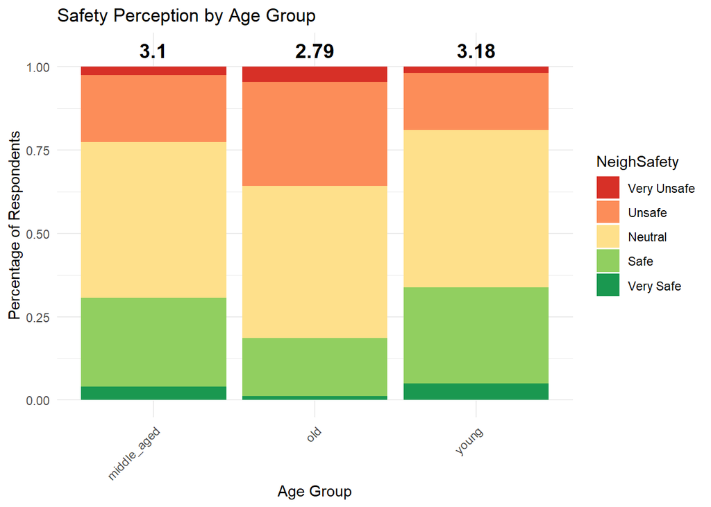

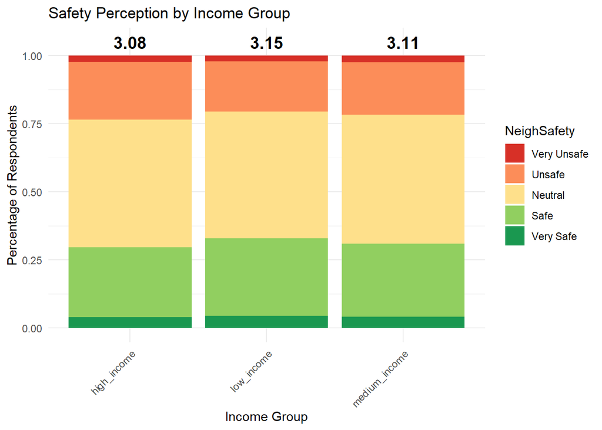

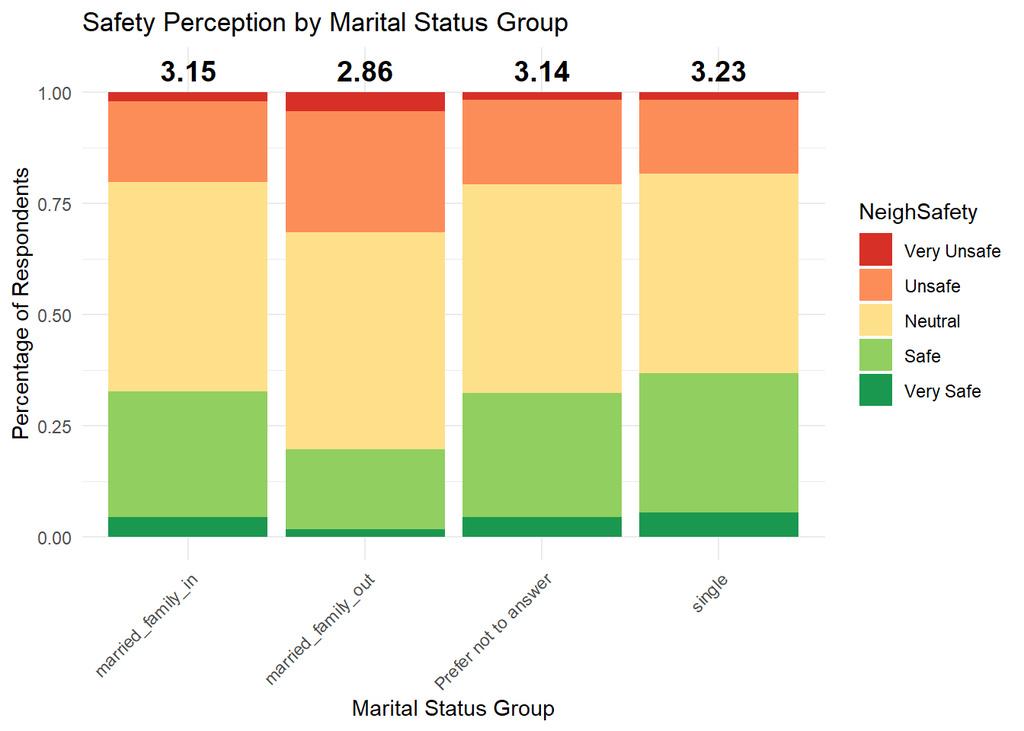

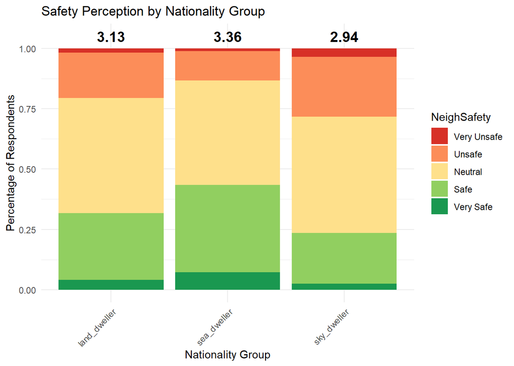

```r
# Load necessary libraries
library(dplyr)
library(ggplot2)

# Convert NeighSafety into a factor with meaningful labels
hh_survey <- hh_survey %>%
  mutate(NeighSafety = factor(NeighSafety,
                              levels = c(1, 2, 3, 4, 5),
                              labels = c("Very Unsafe", "Unsafe", "Neutral", "Safe", "Very Safe")))

# Function to compute safety perception distributions and average scores
compute_safety_stats <- function(group_var) {
  safety_dist <- hh_survey %>%
    group_by(.data[[group_var]], NeighSafety) %>%
    summarise(Count = n(), .groups = "drop") %>%
    group_by(.data[[group_var]]) %>%
    mutate(Percentage = (Count / sum(Count)) * 100)

  avg_safety <- hh_survey %>%
    group_by(.data[[group_var]]) %>%
    summarise(Average_Safety_Score = mean(as.numeric(NeighSafety), na.rm = TRUE), .groups = "drop")

  list(safety_dist = safety_dist, avg_safety = avg_safety)
}

# Define custom colors for safety perception categories
safety_colors <- c("Very Unsafe" = "#D73027",
                   "Unsafe" = "#FC8D59",
                   "Neutral" = "#FEE08B",
                   "Safe" = "#91CF60",
                   "Very Safe" = "#1A9850")

# List of grouping variables and titles
group_vars <- c("InformantGender", "age_group", "income_group", "marital_status_group", "nationality_group")
titles <- c("Gender", "Age Group", "Income Group", "Marital Status Group", "Nationality Group")

# Generate and visualize each stacked bar chart separately
for (i in seq_along(group_vars)) {
  group_var <- group_vars[i]
  title <- titles[i]

  # Compute distributions and average scores
  safety_data <- compute_safety_stats(group_var)

  # Merge data
  safety_plot_data <- left_join(safety_data$safety_dist, safety_data$avg_safety, by = group_var)

  # Create the stacked bar chart
  p <- ggplot(safety_plot_data, aes(x = .data[[group_var]], y = Percentage, fill = NeighSafety)) +
    geom_bar(stat = "identity", position = "fill") +  # 100% stacked bars
    geom_text(data = safety_data$avg_safety, aes(x = .data[[group_var]], y = 1.05, label = round(Average_Safety_Score, 2)),
              inherit.aes = FALSE, hjust = 0.5, size = 5, fontface = "bold") +  # Add average score above each bar
    scale_fill_manual(values = safety_colors) +
    labs(title = paste("Safety Perception by", title),
         x = title,
         y = "Percentage of Respondents") +
    theme_minimal() +
    theme(axis.text.x = element_text(angle = 45, hjust = 1))

  # Print each plot immediately after its code
  print(p)
}
```

# Work Location and Commuting Pattens

Determining whether individuals work within or outside a given study area is typically best handled using geospatial tools such as **ArcGIS or QGIS**, which allow for spatial analysis based on home and workplace coordinates, road networks, and accessibility modeling. These tools provide precise measurements of commuting distances and travel times, often integrating real-world traffic data and land-use information.

However, in certain scenarios, a more approximate approach may be sufficient. For instance:

- When exact workplace locations are unavailable, and only commute modes and travel times are recorded.
- When quick insights are needed without the time or resources to conduct full-scale GIS analyses.
- When working in data-limited environments where only self-reported commuting data is available.
- When a basic stratification of commuters is needed for exploratory analysis before conducting a more detailed spatial study.

In these cases, we can infer work location based on commute mode and duration, using assumptions about typical travel distances per mode. This section explores how to classify work location, analyze differences across socio-economic groups, and visualize work location trends.

## Defining Work Location Based on Commute Patterns

To approximate whether individuals work inside or outside the study area, we apply a **set of thresholds based on their mode of transport and reported commute time**. For instance, a 10-minute car commute or a 30-minute walk is assumed to fall within the study area, while longer commutes are classified as work outside. These classifications serve as a proxy for spatial work distribution in the absence of exact workplace coordinates.

```r
# Define commute thresholds for working within the area
hh_survey <- hh_survey %>%
  mutate(work_group = case_when(
    Informant_workcommute %in% c("Company car/ bus", "Carpool with others",
                                 "Private car owned by someone else", "Private car that they own",
                                 "Uber/Careem", "Taxi") &
      Informant_commutetime <= 10 ~ "work_in",
    Informant_workcommute == "Walking" & Informant_commutetime <= 30 ~ "work_in",
    Informant_workcommute == "Cycling" & Informant_commutetime <= 12 ~ "work_in",
    Informant_workcommute == "Motorcycle" & Informant_commutetime <= 8 ~ "work_in",
    Informant_workcommute == "Public transportation" & Informant_commutetime <= 15 ~ "work_in",
    TRUE ~ "work_out"
  ))

# Check the distribution of work location classification
table(hh_survey$work_group)
```

```
##
##  work_in work_out
##     4355    14145
```

## Work Location Distribution Across Socio-Economic Groups

Once work locations have been classified, we analyze how different nationality, income, and marital status groups are distributed between working inside and outside the area. This breakdown helps identify which groups have greater proximity to employment centers and whether certain populations face longer commutes due to socio-economic constraints.

```r
# Define custom factor levels for proper sorting
hh_survey <- hh_survey %>%
    mutate(income_group = factor(income_group, levels = c("high_income", "medium_income", "low_income")),
           work_group = factor(work_group, levels = c("work_in", "work_out")))

# Compute work location distribution
work_location_by_group <- hh_survey %>%
    group_by(nationality_group, income_group, marital_status_group, work_group) %>%
    summarise(Count = n(), .groups = "drop") %>%
    group_by(nationality_group, income_group, marital_status_group) %>%
    mutate(Percentage = (Count / sum(Count)) * 100) %>%
    arrange(nationality_group, income_group, marital_status_group, work_group)

# Display the results in a table
library(knitr)
kable(work_location_by_group, caption = "Work Location Distribution by Nationality, Income, and Marital Status (Ordered)")
```

Work Location Distribution by Nationality, Income, and Marital Status (Ordered)

| nationality_group | income_group | marital_status_group | work_group | Count | Percentage |
| --- | --- | --- | --- | --- | --- |
| land_dweller | high_income | Prefer not to answer | work_in | 48 | 25.53191 |
| land_dweller | high_income | Prefer not to answer | work_out | 140 | 74.46809 |
| land_dweller | high_income | married_family_in | work_in | 228 | 26.48084 |
| land_dweller | high_income | married_family_in | work_out | 633 | 73.51916 |
| land_dweller | high_income | married_family_out | work_in | 98 | 24.31762 |
| land_dweller | high_income | married_family_out | work_out | 305 | 75.68238 |
| land_dweller | high_income | single | work_in | 149 | 28.00752 |
| land_dweller | high_income | single | work_out | 383 | 71.99248 |
| land_dweller | medium_income | Prefer not to answer | work_in | 57 | 22.26562 |
| land_dweller | medium_income | Prefer not to answer | work_out | 199 | 77.73438 |
| land_dweller | medium_income | married_family_in | work_in | 196 | 21.46769 |
| land_dweller | medium_income | married_family_in | work_out | 717 | 78.53231 |
| land_dweller | medium_income | married_family_out | work_in | 93 | 19.41545 |
| land_dweller | medium_income | married_family_out | work_out | 386 | 80.58455 |
| land_dweller | medium_income | single | work_in | 167 | 23.95983 |
| land_dweller | medium_income | single | work_out | 530 | 76.04017 |
| land_dweller | low_income | Prefer not to answer | work_in | 37 | 17.20930 |
| land_dweller | low_income | Prefer not to answer | work_out | 178 | 82.79070 |
| land_dweller | low_income | married_family_in | work_in | 190 | 20.14846 |
| land_dweller | low_income | married_family_in | work_out | 753 | 79.85154 |
| land_dweller | low_income | married_family_out | work_in | 111 | 21.18321 |
| land_dweller | low_income | married_family_out | work_out | 413 | 78.81679 |
| land_dweller | low_income | single | work_in | 167 | 22.32620 |
| land_dweller | low_income | single | work_out | 581 | 77.67380 |
| sea_dweller | high_income | Prefer not to answer | work_in | 33 | 23.91304 |
| sea_dweller | high_income | Prefer not to answer | work_out | 105 | 76.08696 |
| sea_dweller | high_income | married_family_in | work_in | 169 | 26.08025 |
| sea_dweller | high_income | married_family_in | work_out | 479 | 73.91975 |
| sea_dweller | high_income | married_family_out | work_in | 94 | 32.63889 |
| sea_dweller | high_income | married_family_out | work_out | 194 | 67.36111 |
| sea_dweller | high_income | single | work_in | 101 | 26.16580 |
| sea_dweller | high_income | single | work_out | 285 | 73.83420 |
| sea_dweller | medium_income | Prefer not to answer | work_in | 19 | 16.52174 |
| sea_dweller | medium_income | Prefer not to answer | work_out | 96 | 83.47826 |
| sea_dweller | medium_income | married_family_in | work_in | 112 | 21.29278 |
| sea_dweller | medium_income | married_family_in | work_out | 414 | 78.70722 |
| sea_dweller | medium_income | married_family_out | work_in | 52 | 21.22449 |
| sea_dweller | medium_income | married_family_out | work_out | 193 | 78.77551 |
| sea_dweller | medium_income | single | work_in | 86 | 25.29412 |
| sea_dweller | medium_income | single | work_out | 254 | 74.70588 |
| sea_dweller | low_income | Prefer not to answer | work_in | 39 | 23.21429 |
| sea_dweller | low_income | Prefer not to answer | work_out | 129 | 76.78571 |
| sea_dweller | low_income | married_family_in | work_in | 143 | 20.72464 |
| sea_dweller | low_income | married_family_in | work_out | 547 | 79.27536 |
| sea_dweller | low_income | married_family_out | work_in | 76 | 21.59091 |
| sea_dweller | low_income | married_family_out | work_out | 276 | 78.40909 |
| sea_dweller | low_income | single | work_in | 112 | 20.03578 |
| sea_dweller | low_income | single | work_out | 447 | 79.96422 |
| sky_dweller | high_income | Prefer not to answer | work_in | 69 | 29.11392 |
| sky_dweller | high_income | Prefer not to answer | work_out | 168 | 70.88608 |
| sky_dweller | high_income | married_family_in | work_in | 294 | 26.99725 |
| sky_dweller | high_income | married_family_in | work_out | 795 | 73.00275 |
| sky_dweller | high_income | married_family_out | work_in | 145 | 29.41176 |
| sky_dweller | high_income | married_family_out | work_out | 348 | 70.58824 |
| sky_dweller | high_income | single | work_in | 178 | 24.21769 |
| sky_dweller | high_income | single | work_out | 557 | 75.78231 |
| sky_dweller | medium_income | Prefer not to answer | work_in | 38 | 20.54054 |
| sky_dweller | medium_income | Prefer not to answer | work_out | 147 | 79.45946 |
| sky_dweller | medium_income | married_family_in | work_in | 191 | 21.82857 |
| sky_dweller | medium_income | married_family_in | work_out | 684 | 78.17143 |
| sky_dweller | medium_income | married_family_out | work_in | 113 | 27.16346 |
| sky_dweller | medium_income | married_family_out | work_out | 303 | 72.83654 |
| sky_dweller | medium_income | single | work_in | 161 | 25.27473 |
| sky_dweller | medium_income | single | work_out | 476 | 74.72527 |
| sky_dweller | low_income | Prefer not to answer | work_in | 51 | 20.64777 |
| sky_dweller | low_income | Prefer not to answer | work_out | 196 | 79.35223 |
| sky_dweller | low_income | married_family_in | work_in | 243 | 22.94618 |
| sky_dweller | low_income | married_family_in | work_out | 816 | 77.05382 |
| sky_dweller | low_income | married_family_out | work_in | 118 | 23.22835 |
| sky_dweller | low_income | married_family_out | work_out | 390 | 76.77165 |
| sky_dweller | low_income | single | work_in | 177 | 21.98758 |
| sky_dweller | low_income | single | work_out | 628 | 78.01242 |

## Visualizing Work Location Trends

- **Work Location by Income Group:** Reveals differences in job accessibility based on economic status.
- **Work Location by Economic Activity:** Identifies the industries where workers are more likely to be employed within the study area, revealing sectoral differences in work location patterns. These insights help inform urban planning, transport policy, and employment accessibility strategies within the study area.

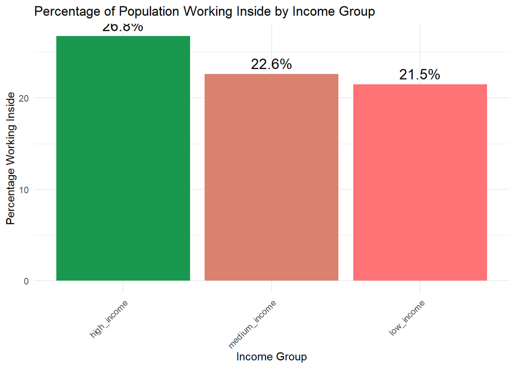

```r
# Shorten long economic activity names for better visualization
hh_survey <- hh_survey %>%
    mutate(Short_Econ_Activity = case_when(
        Informant_econactivity == "Agriculture, Forestry, and Fishing" ~ "Agriculture",
        Informant_econactivity == "Information and Communication Technology (ICT)" ~ "ICT",
        Informant_econactivity == "Retail and Wholesale Trade" ~ "Retail & Trade",
        TRUE ~ Informant_econactivity
    ))

# Compute the percentage of people working inside for each group
work_inside_by_income <- hh_survey %>%
    group_by(income_group) %>%
    summarise(Work_Inside = mean(work_group == "work_in", na.rm = TRUE) * 100)

work_inside_by_econ_activity <- hh_survey %>%
    group_by(Short_Econ_Activity) %>%
    summarise(Work_Inside = mean(work_group == "work_in", na.rm = TRUE) * 100)

# Define plot function
plot_work_inside <- function(data, x_var, title, x_label) {
    ggplot(data, aes(x = reorder(.data[[x_var]], -Work_Inside), y = Work_Inside, fill = Work_Inside)) +
        geom_bar(stat = "identity") +
        geom_text(aes(label = paste0(round(Work_Inside, 1), "%")), vjust = -0.5, size = 5) +
        scale_fill_gradient(low = "#FF7276", high = "#1A9850") +  # Gradient from red (low) to green (high)
        labs(title = title, x = x_label, y = "Percentage Working Inside") +
        theme_minimal() +
        theme(axis.text.x = element_text(angle = 45, hjust = 1), legend.position = "none")
}

# Generate and display the plots sequentially
plot_work_inside(work_inside_by_income, "income_group", "Percentage of Population Working Inside by Income Group", "Income Group")
```

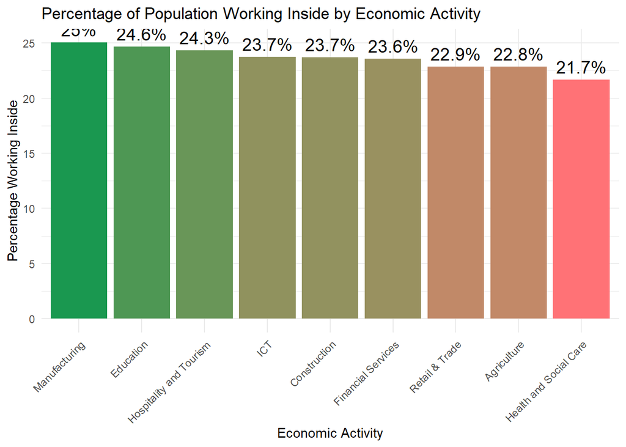

```r
plot_work_inside(work_inside_by_econ_activity, "Short_Econ_Activity", "Percentage of Population Working Inside by Economic Activity", "Economic Activity")
```